# T2 - Exercicis de les diapositives

## Exemples 1-3

- Benzina consumida al conduir un cotxe:

```r
x = seq(0, 1000, by=100)
y = 7.5 * (x/100)
# Agrupam les dades i les mostram per pantalla
kable(head(data.frame(x, y)))
```

| x | y |
| --- | --- |
| 0 | 0.0 |
| 100 | 7.5 |
| 200 | 15.0 |
| 300 | 22.5 |
| 400 | 30.0 |
| 500 | 37.5 |

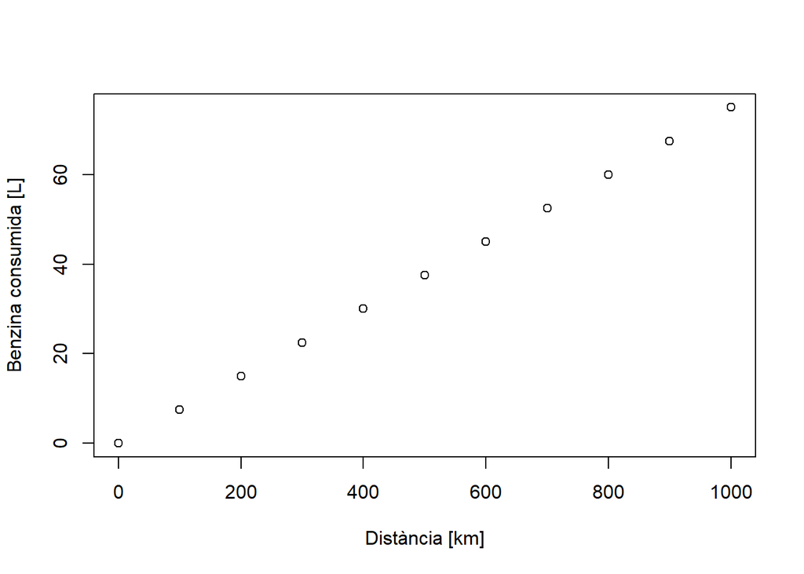

```r
# Feim la gràfica per visualitzar la funció
plot(x, y, xlab = 'Distància [km]', ylab = 'Benzina consumida [L]')
```

Mostrem-la de forma contínua:

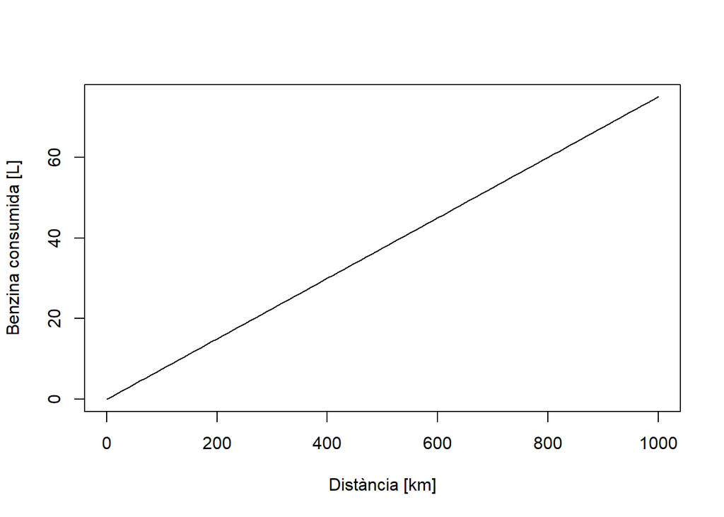

```r
curve(7.5 * (x/100), 0, 1000, xlab = 'Distància [km]', ylab = 'Benzina consumida [L]')
```

- Desintegració radioactiva de l’Urani-235

Començam visualitzant la dependència:

```r
t = 0:100
q = 100 * 0.5^(t/703.8)
kable(head(data.frame(t, q)))
```

| t | q |
| --- | --- |
| 0 | 100.00000 |
| 1 | 99.90156 |
| 2 | 99.80322 |
| 3 | 99.70498 |
| 4 | 99.60683 |
| 5 | 99.50878 |

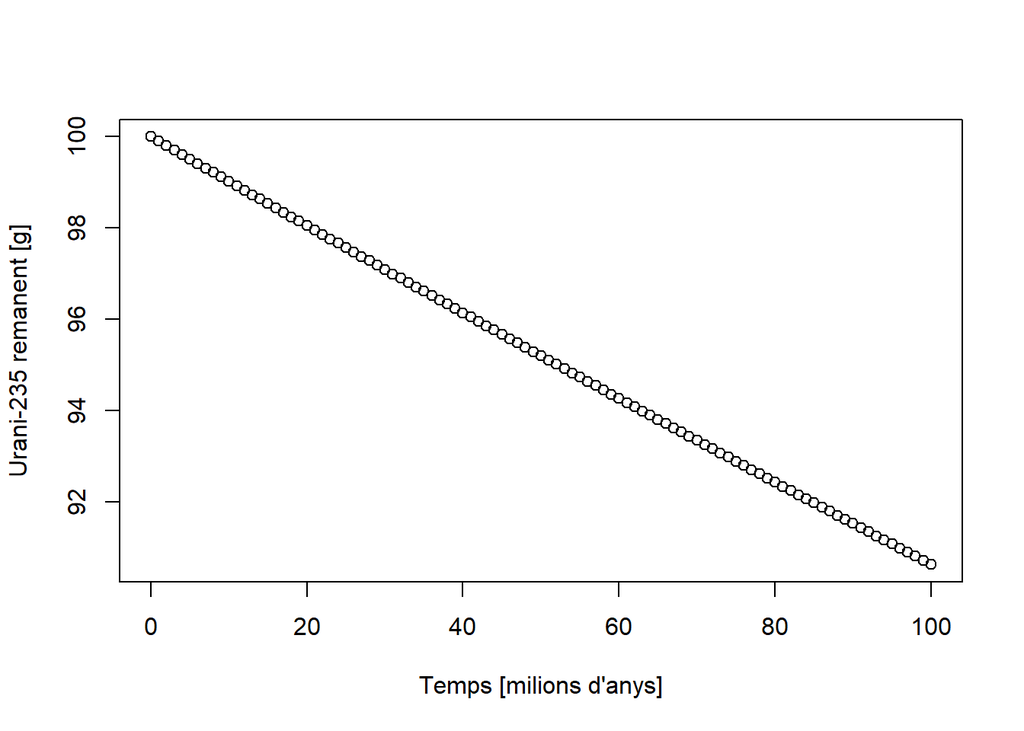

```r
plot(t, q, xlab = 'Temps [milions d\'anys]', ylab = 'Urani-235 remanent [g]')
```

Podem visualitzar-ho a diverses escales:

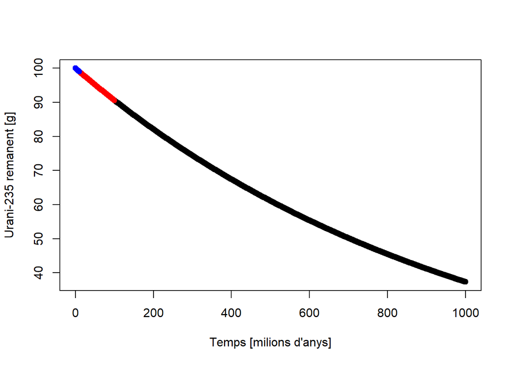

```r
plot(0:1000, 100 * 0.5^(0:1000/703.8), xlab = 'Temps [milions d\'anys]', ylab = 'Urani-235 remanent [g]')
points(0:100, 100 * 0.5^(0:100/703.8), col='red')
points(0:10, 100 * 0.5^(0:10/703.8), col='blue')
```

- Pes i alçada d’adults sans

Visualitzem el model 1:

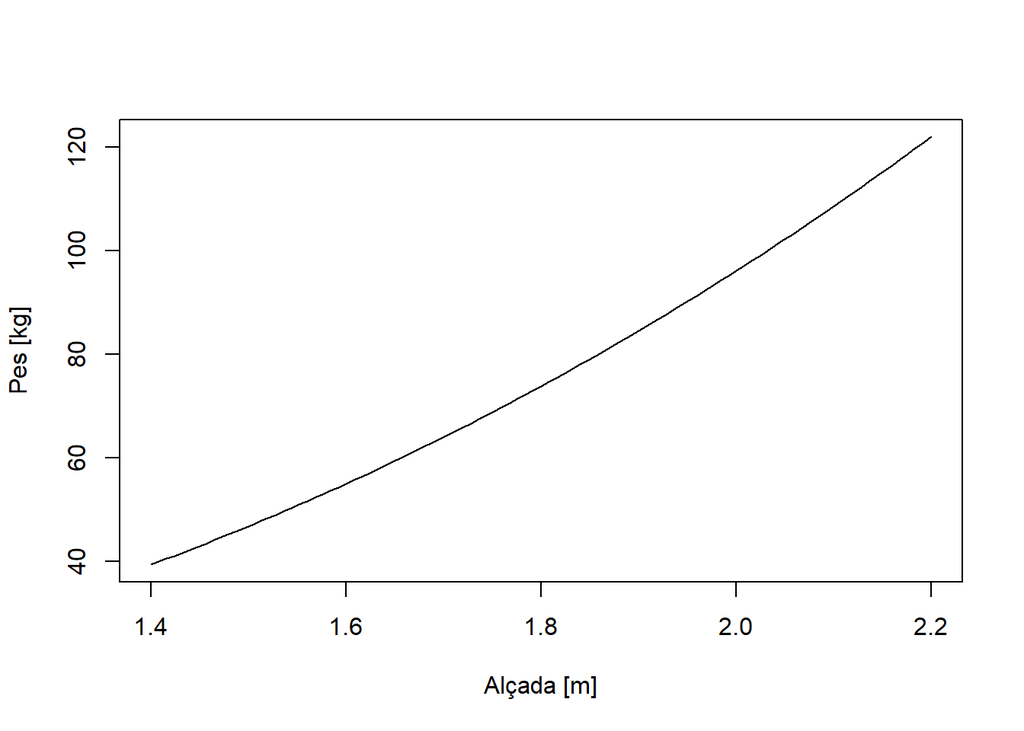

```r
curve(17*x^2.5, 1.40, 2.20, xlab = 'Alçada [m]', ylab = 'Pes [kg]')
```

Visualitzem ara el model 3, on ara l’alçada depèn del pes:

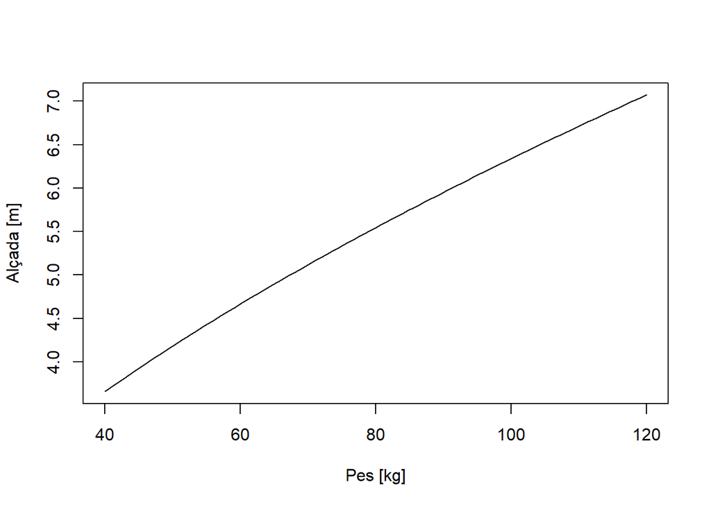

```r
curve(0.4 * x^0.6, 40, 120, xlab = 'Pes [kg]', ylab = 'Alçada [m]')
```

## Exemple 3

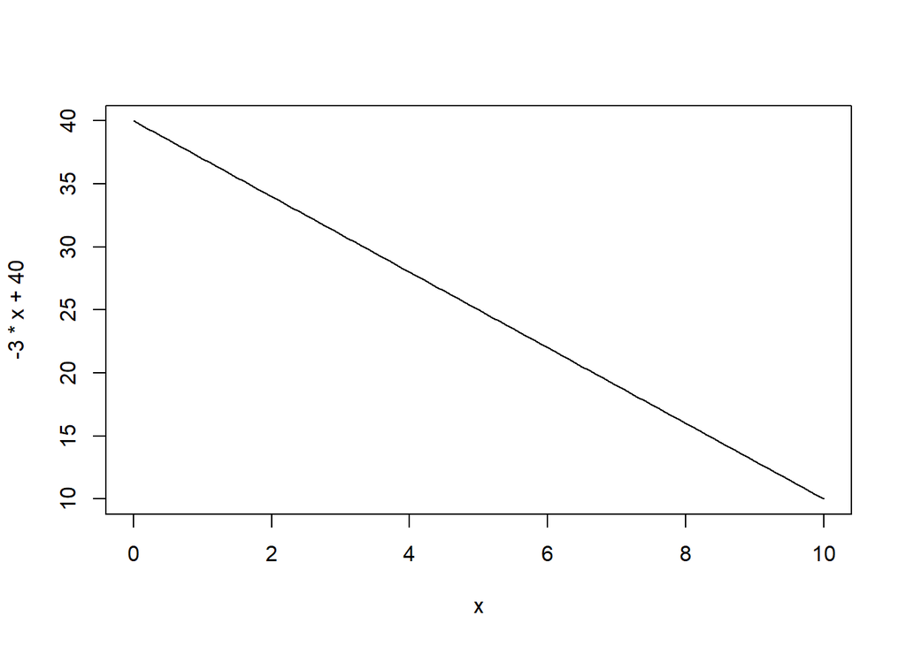

```r
curve(-3*x+40,0,10)
```

## Exemple 4

Introduïm les dades i les mostram

```r
df = data.frame(
  temps=c(10, 20, 30, 40, 50),
  concentracio=c(44, 35.2, 29.5, 25.8, 22.3)
)
kable(df)
```

| temps | concentracio |
| --- | --- |
| 10 | 44.0 |
| 20 | 35.2 |
| 30 | 29.5 |
| 40 | 25.8 |
| 50 | 22.3 |

```r
plot(df$temps, df$concentracio)         # Fer gràfica dels punts
```

[output not shown]

Calcularem un model de regressió lineal, i mostrarem

```r
# Calcular model lineal de concentració en funció del temps
model = lm(concentracio~temps, data=df)
# Mostram els coeficients del model
summary(model)
```

```
##
## Call:
## lm(formula = concentracio ~ temps, data = df)
##
## Residuals:
##     1     2     3     4     5
##  2.08 -1.44 -1.86 -0.28  1.50
##
## Coefficients:
##             Estimate Std. Error t value Pr(>|t|)
## (Intercept) 47.20000    2.11399  22.327 0.000197 ***
## temps       -0.52800    0.06374  -8.284 0.003685 **
## ---
## Signif. codes:  0 '***' 0.001 '**' 0.01 '*' 0.05 '.' 0.1 ' ' 1
##
## Residual standard error: 2.016 on 3 degrees of freedom
## Multiple R-squared:  0.9581, Adjusted R-squared:  0.9442
## F-statistic: 68.62 on 1 and 3 DF,  p-value: 0.003685
```

També podem visualitzar-ho en una gràfica:

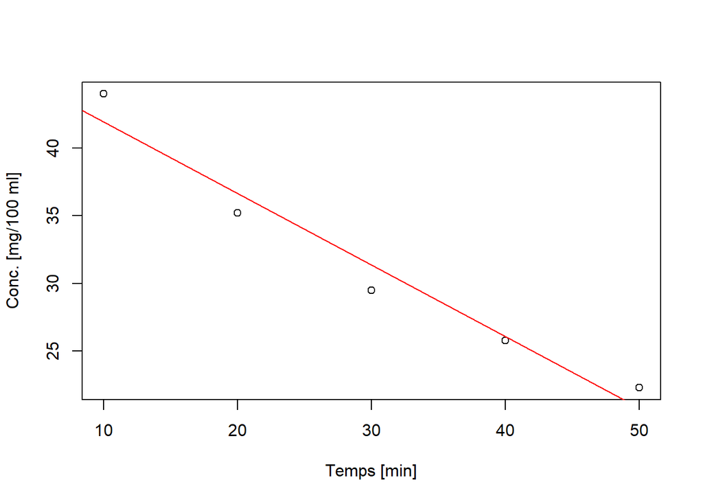

```r
# Fer gràfica dels punts
plot(
    x=df$temps,
    y=df$concentracio,
    xlab="Temps [min]",
    ylab="Conc. [mg/100 ml]"
)
# Afegir la recta del model de regressió
abline(model, col='red')
```

## Exercicis 5-6

- $f(x) = 10^x$

Mostrem només els eixos:

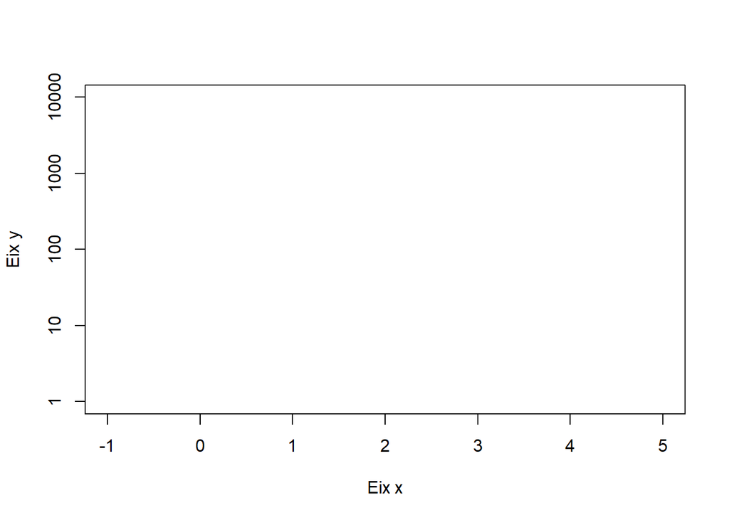

```r
plot(0, log="y",
     xlim=c(-1, 5), xlab="Eix x",
     ylim=c(1, 1e4), ylab="Eix y")
```

I visualitzem ara els punts i, unint-los, l’equació que volem trobar

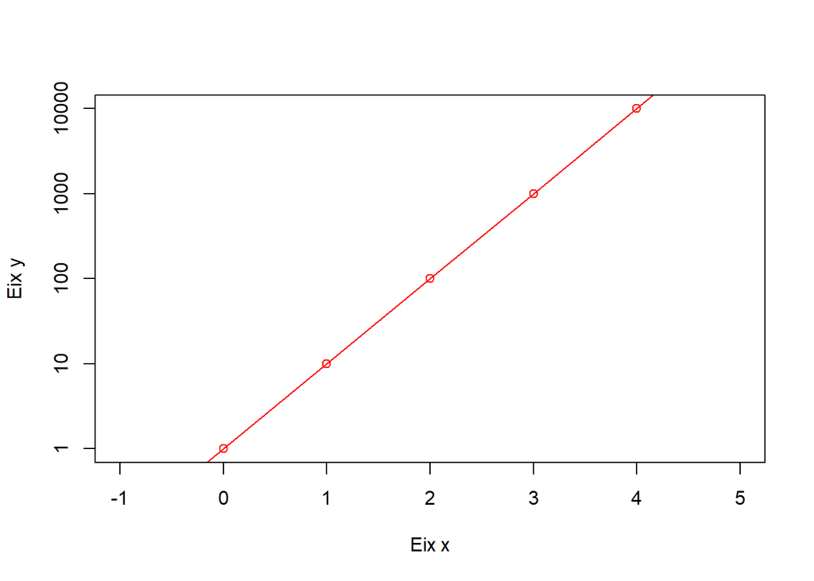

```r
x = -1:5
y = 10^x
plot(x, y, col="red", type='o', log="y",
     xlim=c(-1, 5), xlab="Eix x",
     ylim=c(1, 1e4), ylab="Eix y")
```

- $g(x) = 0.1 \cdot 10^x$

De nou, mostrem els eixos buits:

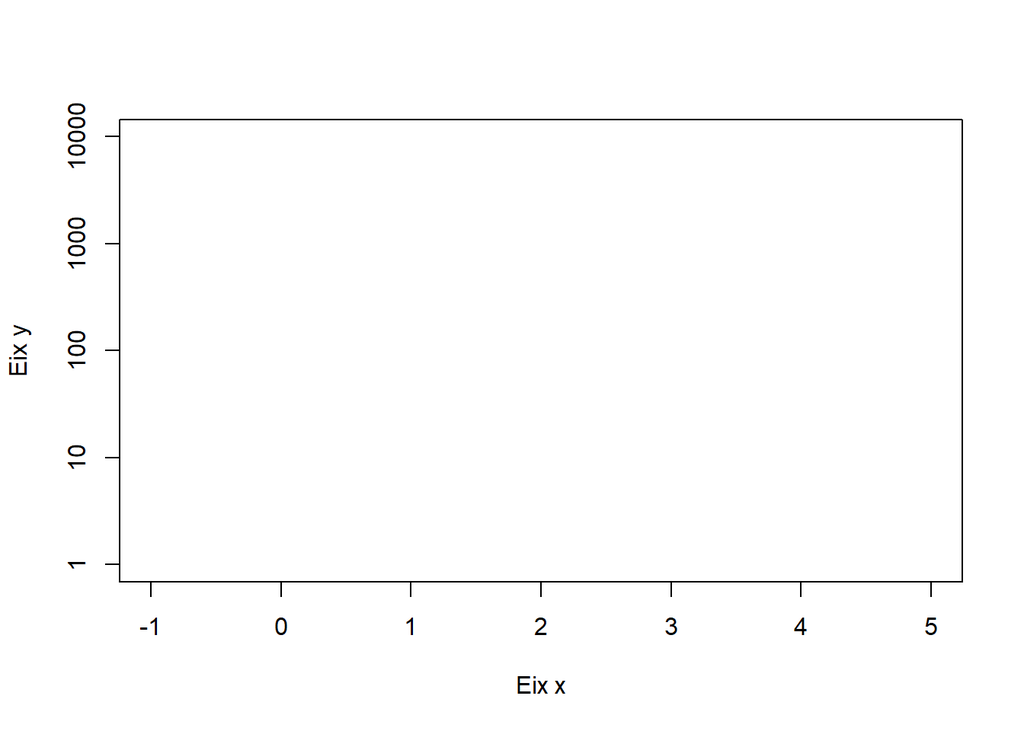

```r
plot(0, log="y",
     xlim=c(-1, 5), xlab="Eix x",
     ylim=c(1, 1e4), ylab="Eix y")
```

I dibuixem els punts que ens interessen

```r
x = -1:5
y = 0.1 * 10^x
# Agrupam els punts (x, y(x)) i els mostram
kable(data.frame(x, y))
```

| x | y |
| --- | --- |
| -1 | 1e-02 |
| 0 | 1e-01 |
| 1 | 1e+00 |
| 2 | 1e+01 |
| 3 | 1e+02 |
| 4 | 1e+03 |
| 5 | 1e+04 |

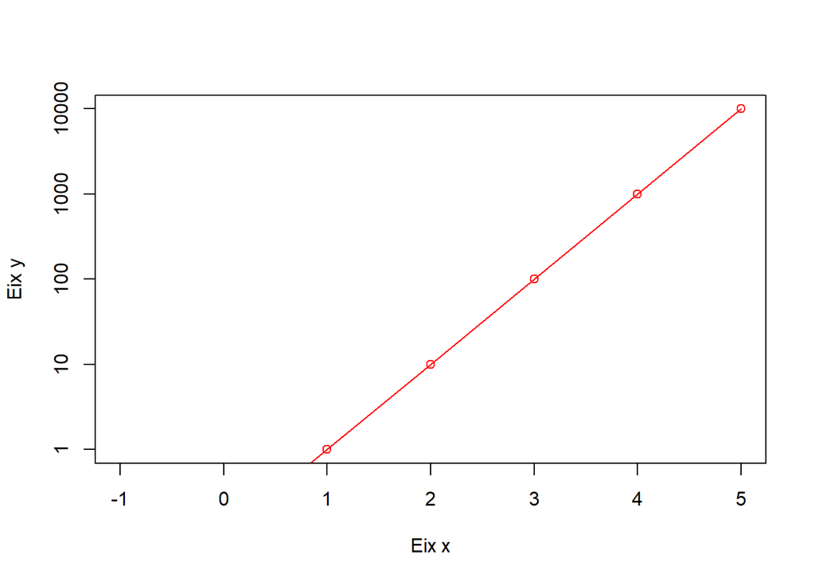

```r
# Visualitzam la gràfica
plot(x, y, col="red", type='o', log="y",
     xlim=c(-1, 5), xlab="Eix x",
     ylim=c(1, 1e4), ylab="Eix y")
```

## Exercici 7-8

Si ho feim de la següent forma no és correcte ja que l’eix vertical ha de representar la variable $y$, no la variable $Y$. De fet, l’eix vertical està en escala lineal!:

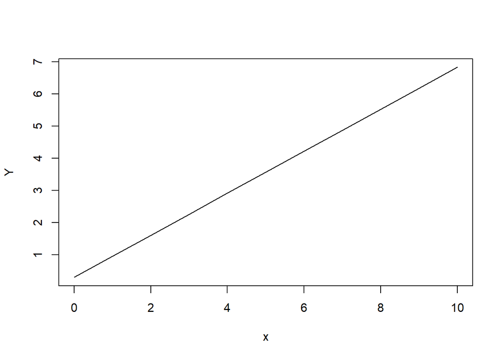

```r
x = 0:10
y = 2 * 4.5^x
Y = log10(y)
plot(x, Y, type="l")
```

La versió correcta és:

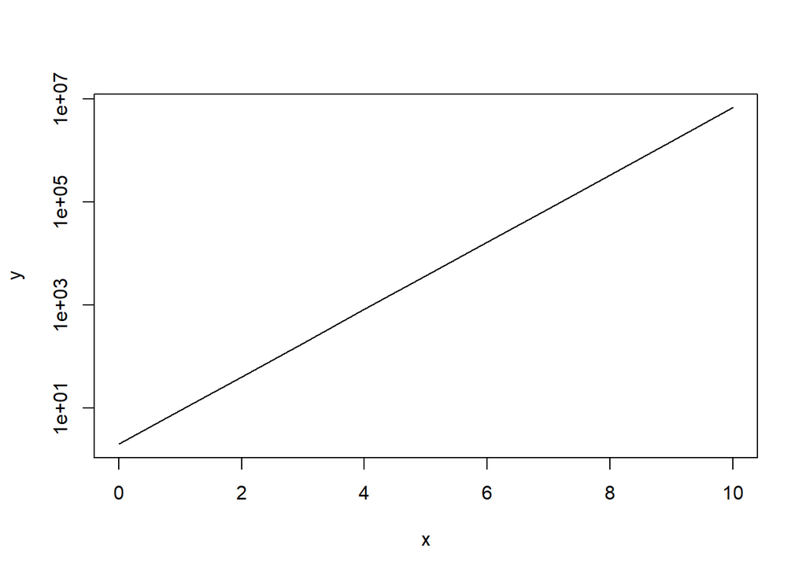

```r
x = 0:10
y = 2 * 4.5^x
plot(x, y, type="l", log="y")
```

## Exemple 9

Introduïm les dades i les mostram

```r
df = data.frame(
  temps=c(10, 20, 30, 40, 50),
  concentracio=c(44, 35.2, 29.5, 25.8, 22.3)
)
kable(df)
```

| temps | concentracio |
| --- | --- |
| 10 | 44.0 |
| 20 | 35.2 |
| 30 | 29.5 |
| 40 | 25.8 |
| 50 | 22.3 |

```r
plot(df$temps, df$concentracio)
```

[output not shown]

Calcularem un model de regressió exponencial de la concentració en funció del temps, i mostrarem

```r
# Calcular model lineal de concentració en funció del temps
model_exp = lm(
  log10(concentracio)~temps,
  data=df
)
# Mostram els coeficients del model
summary(model_exp)
```

```
##
## Call:
## lm(formula = log10(concentracio) ~ temps, data = df)
##
## Residuals:
##          1          2          3          4          5
##  0.0144606 -0.0099276 -0.0141264  0.0001932  0.0094002
##
## Coefficients:
##               Estimate Std. Error t value Pr(>|t|)
## (Intercept)  1.7015140  0.0147782  115.14 1.44e-06 ***
## temps       -0.0072522  0.0004456  -16.28 0.000505 ***
## ---
## Signif. codes:  0 '***' 0.001 '**' 0.01 '*' 0.05 '.' 0.1 ' ' 1
##
## Residual standard error: 0.01409 on 3 degrees of freedom
## Multiple R-squared:  0.9888, Adjusted R-squared:  0.9851
## F-statistic: 264.9 on 1 and 3 DF,  p-value: 0.0005046
```

També podem visualitzar-ho en una gràfica semi-log:

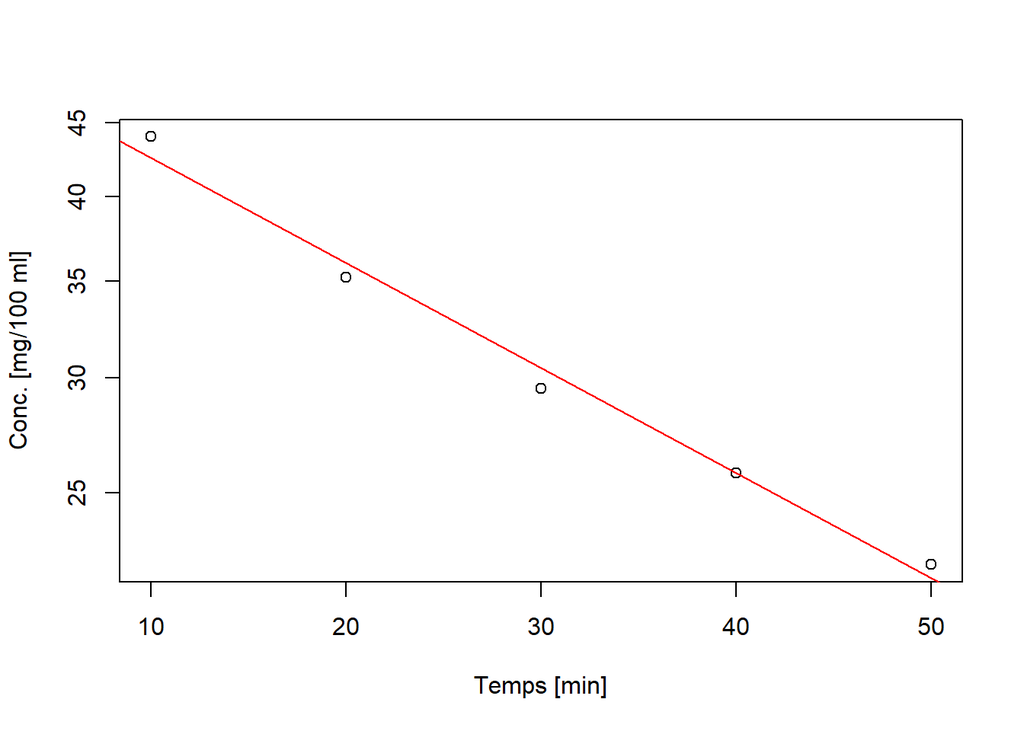

```r
# Fer gràfica dels punts
plot(
    x=df$temps,
    y=df$concentracio,
    xlab="Temps [min]",
    ylab="Conc. [mg/100 ml]",
    log="y"
)
# Afegir la recta del model de regressió
abline(model_exp, col='red')
```

Finalment, vegem-ho en una gràfica lineal:

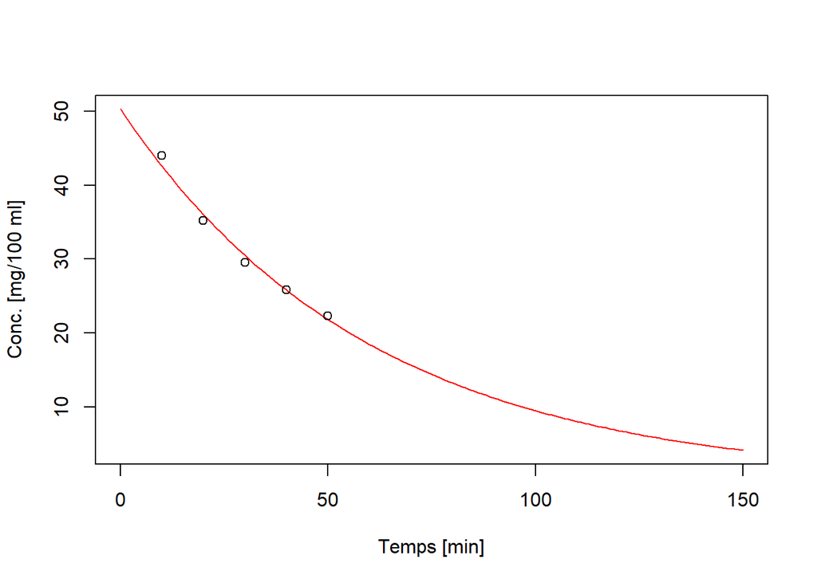

```r
# Calcular prediccions noves
df_model = data.frame(temps=0:150)
df_model$pred = 10^predict(model_exp, df_model)
# Mostrar la corba del model de regressió
plot(
    x=df_model$temps,
    y=df_model$pred,
    col='red', type="l",
    xlab="Temps [min]",
    ylab="Conc. [mg/100 ml]",)
# Afegir les dades originals
points(
    x=df$temps,
    y=df$concentracio,
)
```

També podem representar directament la funció exponencial obtinguda:

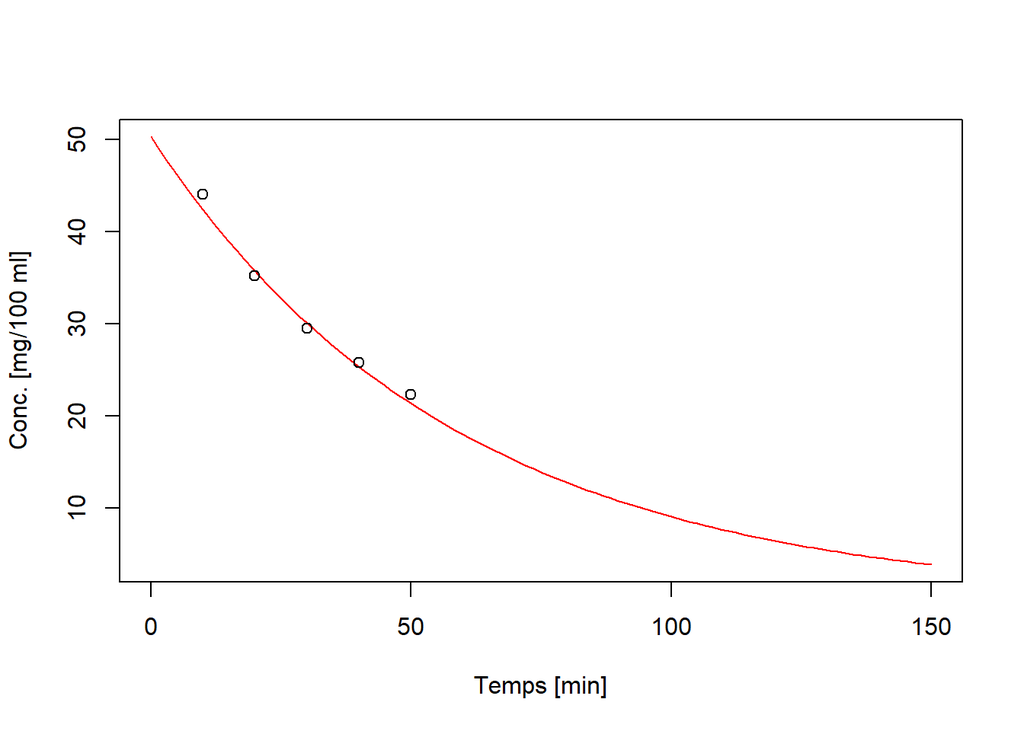

```r
curve(50.29*0.983^x,0,150,col="red",xlab="Temps [min]",
    ylab="Conc. [mg/100 ml]")
points(x=df$temps, y=df$concentracio)
```

## Exercicis 10-11

- Gràfica semi-log

Calculem els punts que ens demanen:

```r
x = 1:6
y = 4*x^2
kable(data.frame(x, y))
```

| x | y |
| --- | --- |
| 1 | 4 |
| 2 | 16 |
| 3 | 36 |
| 4 | 64 |
| 5 | 100 |
| 6 | 144 |

Mostrem els eixos:

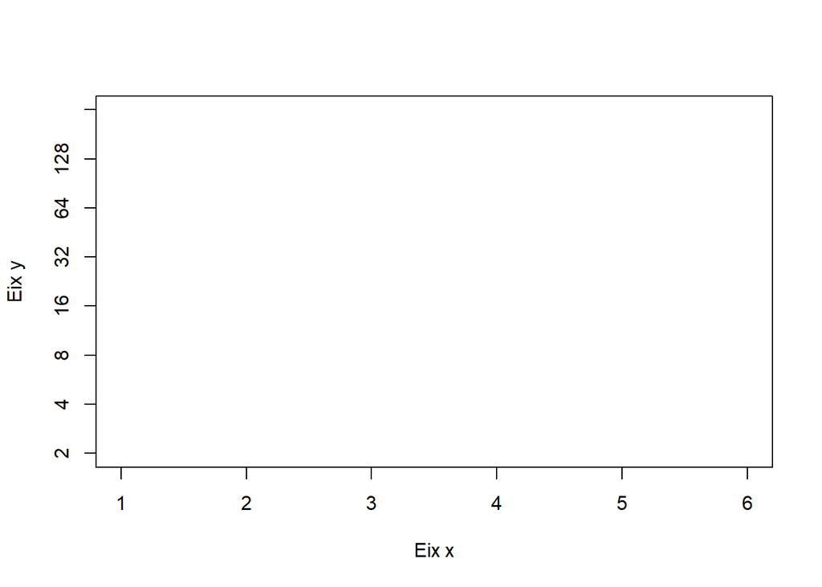

```r
plot(0.1, log="y",
     xlim=c(1, 6), xlab="Eix x",
     ylim=c(2, 2^8), ylab="Eix y", yaxt="n")
axis(side=2, at=2^c(1:8))
```

Visualitzem ara els punts en aquesta gràfica semi-log:

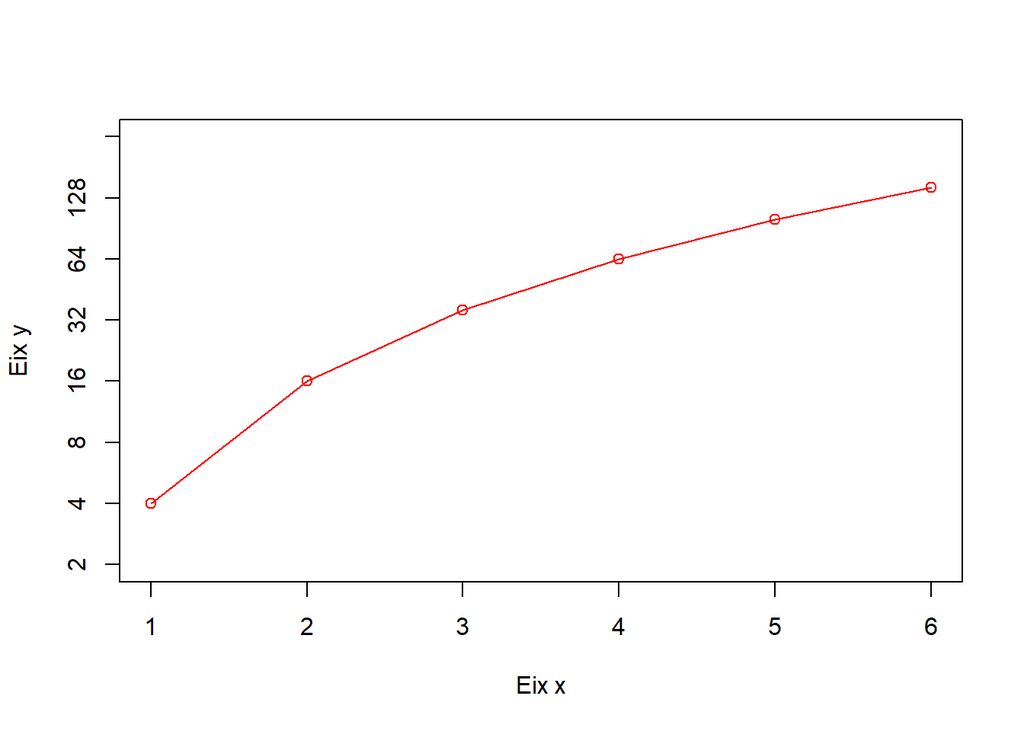

```r
plot(x, y, col="red", type='o', log="y",
     xlim=c(1, 6), xlab="Eix x",
     ylim=c(2, 2^8), ylab="Eix y", yaxt="n")
axis(side=2, at=2^c(1:8))
```

- Gràfica log-log

De nou, mostrem els eixos:

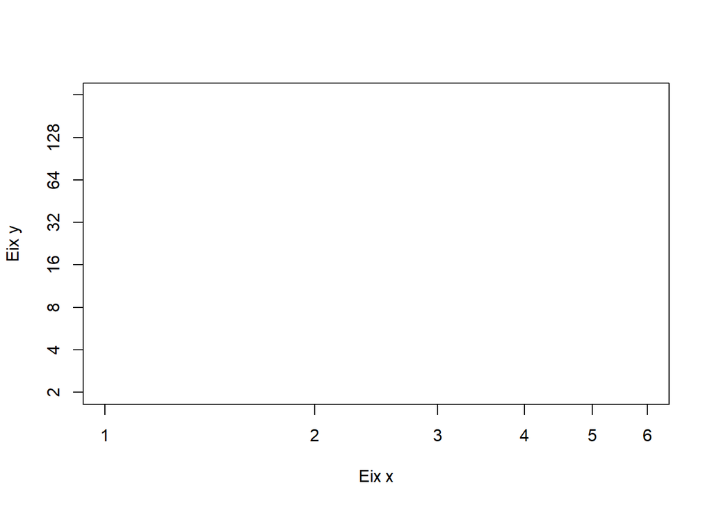

```r
plot(0.1, log="xy",
     xlim=c(1, 6), xlab="Eix x",
     ylim=c(2, 2^8), ylab="Eix y", yaxt="n")
axis(side=2, at=2^c(1:8))
```

Finalment, visualitzem els punts en la gràfica log-log:

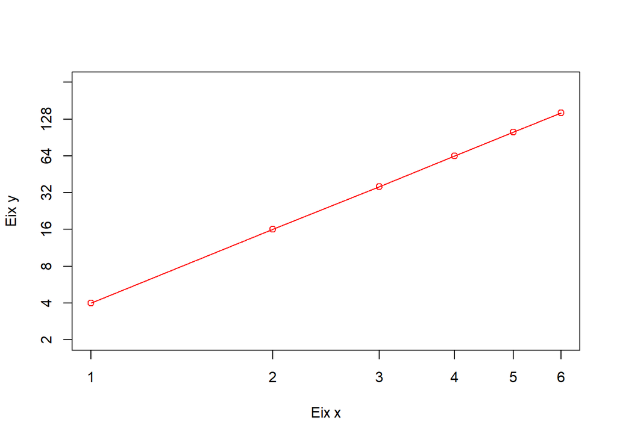

```r
x = 1:6
y = 4*x^2
plot(x, y, col="red", type='o', log="xy",
     xlim=c(1, 6), xlab="Eix x",
     ylim=c(2, 2^8), ylab="Eix y", yaxt="n")
axis(side=2, at=2^c(1:8))
```

## Exemple 12

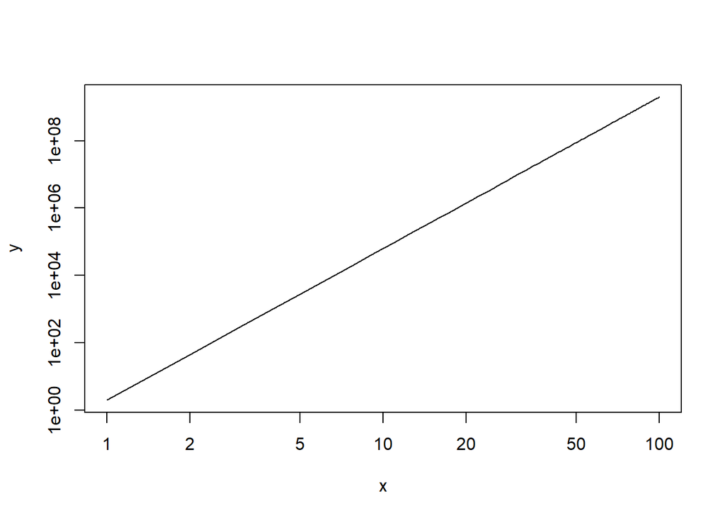

```r
x = 1:100
y = 2 * x^4.5
plot(x, y, log="xy", type="l")
```

## Exemple 13

Introduïm les dades i les mostram

```r
df = data.frame(
  temps=c(10, 20, 30, 40, 50),
  concentracio=c(44, 35.2, 29.5, 25.8, 22.3)
)
kable(df)
```

| temps | concentracio |
| --- | --- |
| 10 | 44.0 |
| 20 | 35.2 |
| 30 | 29.5 |
| 40 | 25.8 |
| 50 | 22.3 |

```r
plot(df$temps, df$concentracio)
```

[output not shown]

Calcularem un model de regressió potencial de la concentració en funció del temps, i mostrarem

```r
# Calcular model lineal de concentració en funció del temps
model_pot = lm(
  log10(concentracio)~log10(temps),
  data=df
)
# Mostram els coeficients del model
summary(model_pot)
```

```
##
## Call:
## lm(formula = log10(concentracio) ~ log10(temps), data = df)
##
## Residuals:
##         1         2         3         4         5
## -0.012800  0.015024  0.011267  0.004834 -0.018325
##
## Coefficients:
##              Estimate Std. Error t value Pr(>|t|)
## (Intercept)   2.07061    0.04448   46.55 2.18e-05 ***
## log10(temps) -0.41436    0.03095  -13.39 0.000901 ***
## ---
## Signif. codes:  0 '***' 0.001 '**' 0.01 '*' 0.05 '.' 0.1 ' ' 1
##
## Residual standard error: 0.01708 on 3 degrees of freedom
## Multiple R-squared:  0.9835, Adjusted R-squared:  0.978
## F-statistic: 179.2 on 1 and 3 DF,  p-value: 0.000901
```

També podem visualitzar-ho en una gràfica log-log:

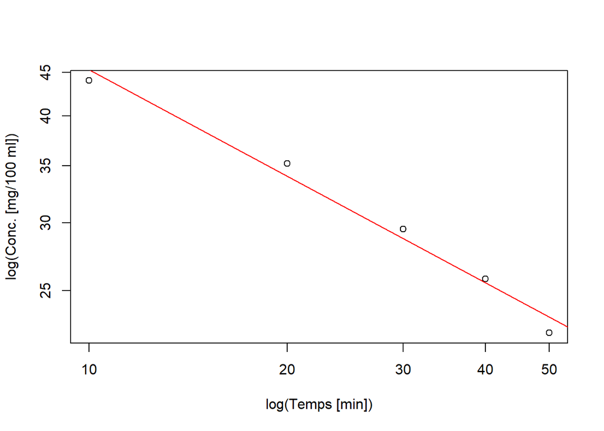

```r
# Fer gràfica dels punts
plot(
    x=df$temps,
    y=df$concentracio,
    xlab="log(Temps [min])",
    ylab="log(Conc. [mg/100 ml])",
    log="xy"
)
# Afegir la recta del model de regressió
abline(model_pot, col='red')
```

Finalment, vegem-ho en una gràfica lineal:

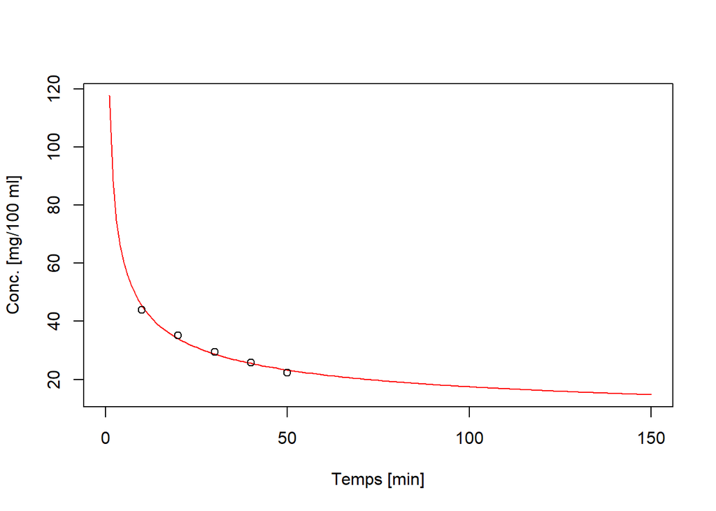

```r
# Calcular prediccions noves
df_model = data.frame(temps=0:150)
df_model$pred = 10^predict(model_pot, df_model)
# Mostrar la corba del model de regressió
plot(
    x=df_model$temps,
    y=df_model$pred,
    col='red', type="l",
    xlab="Temps [min]",
    ylab="Conc. [mg/100 ml]",)
# Afegir les dades originals
points(
    x=df$temps,
    y=df$concentracio,
)
```

També ho podem fer representant directament la funció trobada:

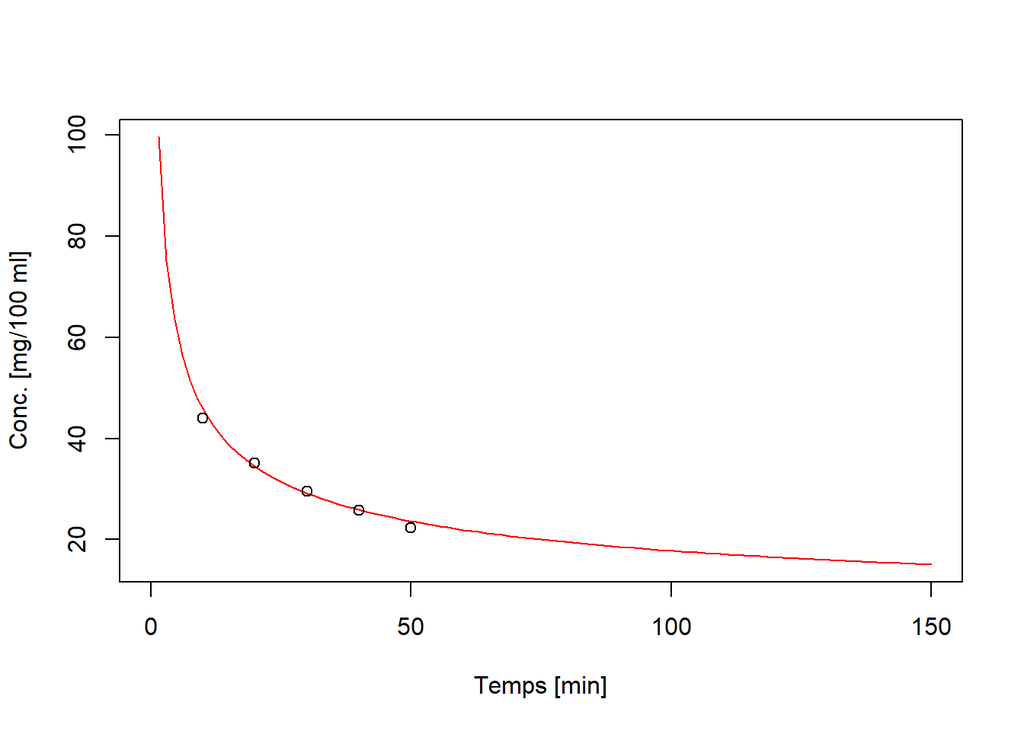

```r
curve(117.65*x^{-0.41},0,150,col="red",xlab="Temps [min]",
    ylab="Conc. [mg/100 ml]")
points(x=df$temps, y=df$concentracio)
```

## Exercici 14

Visualitzarem la relació en una gràfica lineal, semilog i log-log:

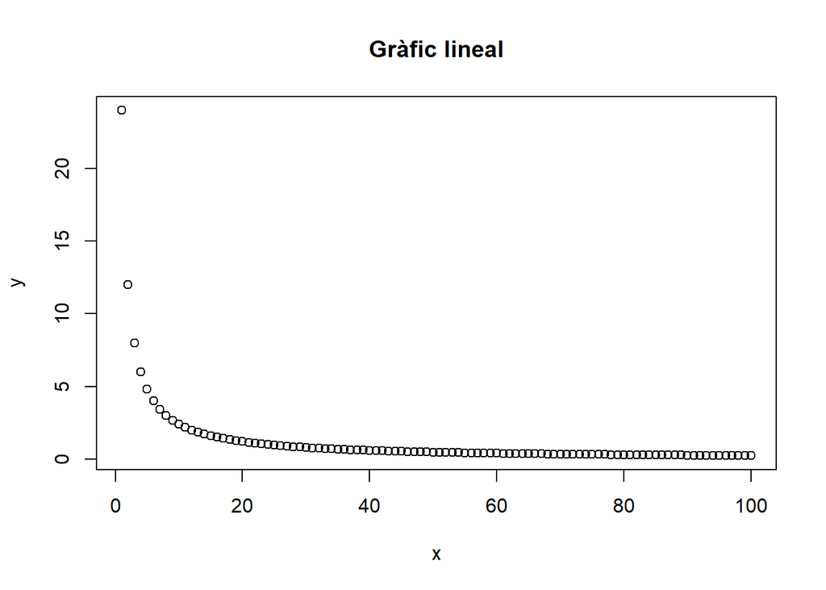

```r
x = 1:100
y = 8/(x^1/3)
plot(x, y, main="Gràfic lineal")
```

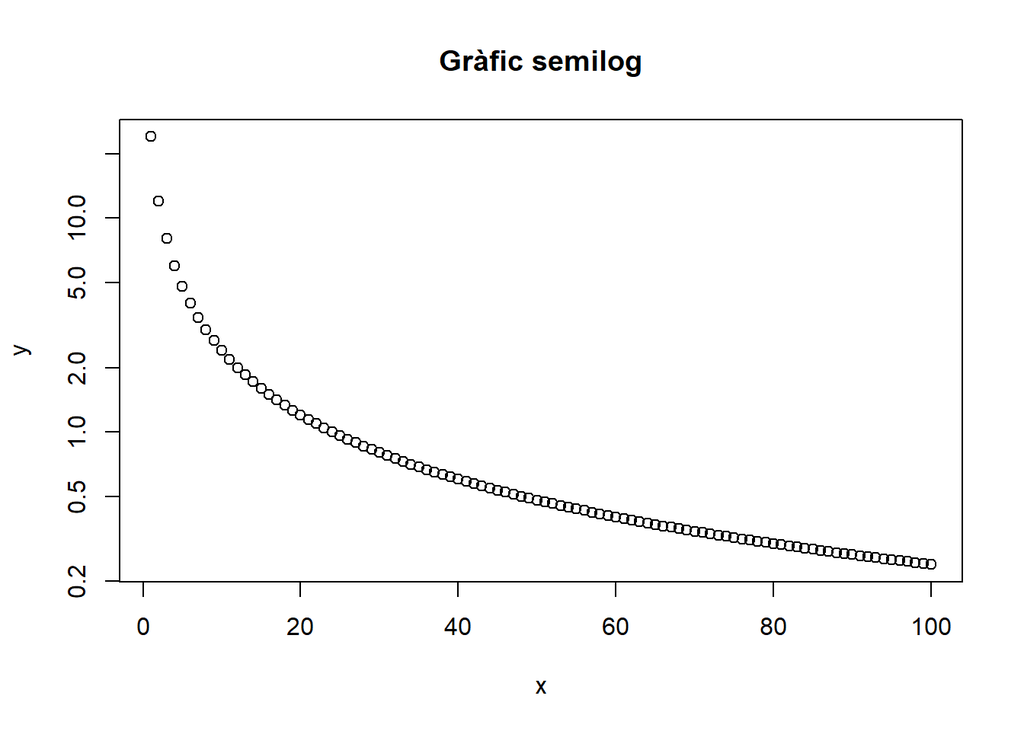

```r
plot(x, y, main="Gràfic semilog", log="y")
```

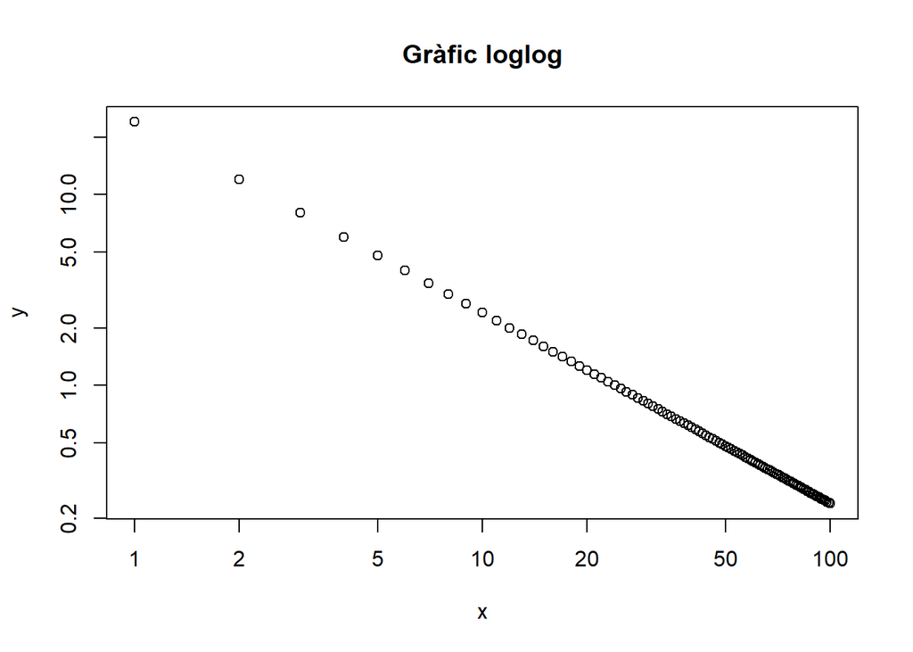

```r
plot(x, y, main="Gràfic loglog", log="xy")
```

## Exercici 15

Visualitzarem les dades en una gràfica lineal, semilog i log-log:

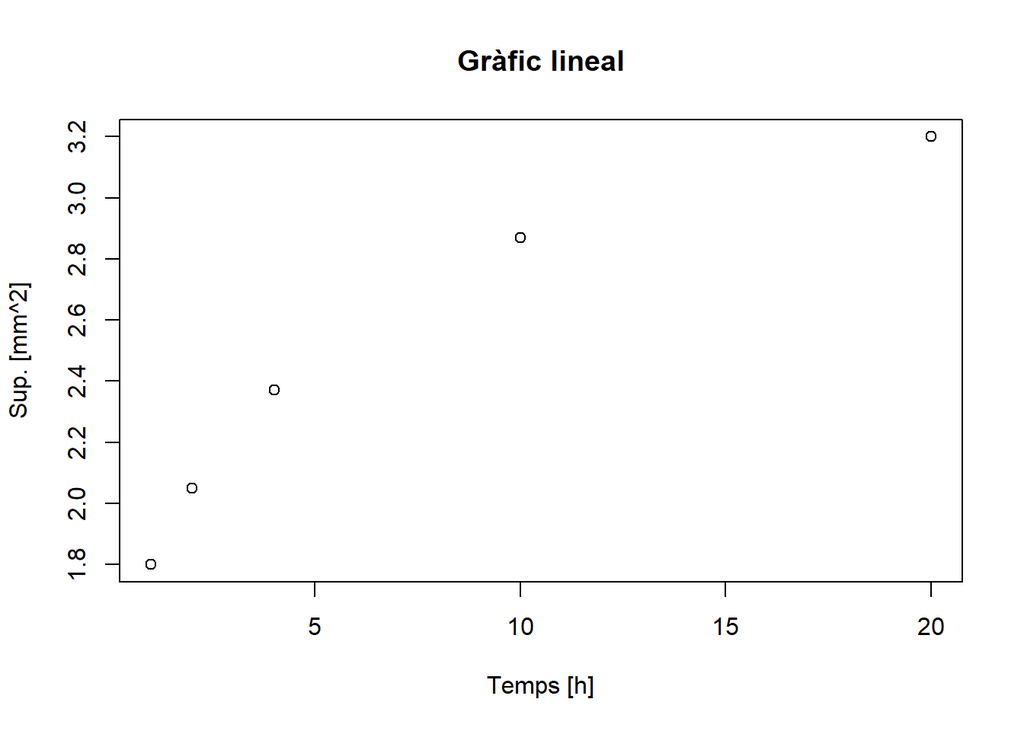

```r
t = c(1, 2, 4, 10, 20)
s = c(1.8, 2.05, 2.37, 2.87, 3.2)
plot(t, s, xlab="Temps [h]", ylab="Sup. [mm^2]",
     main="Gràfic lineal")
```

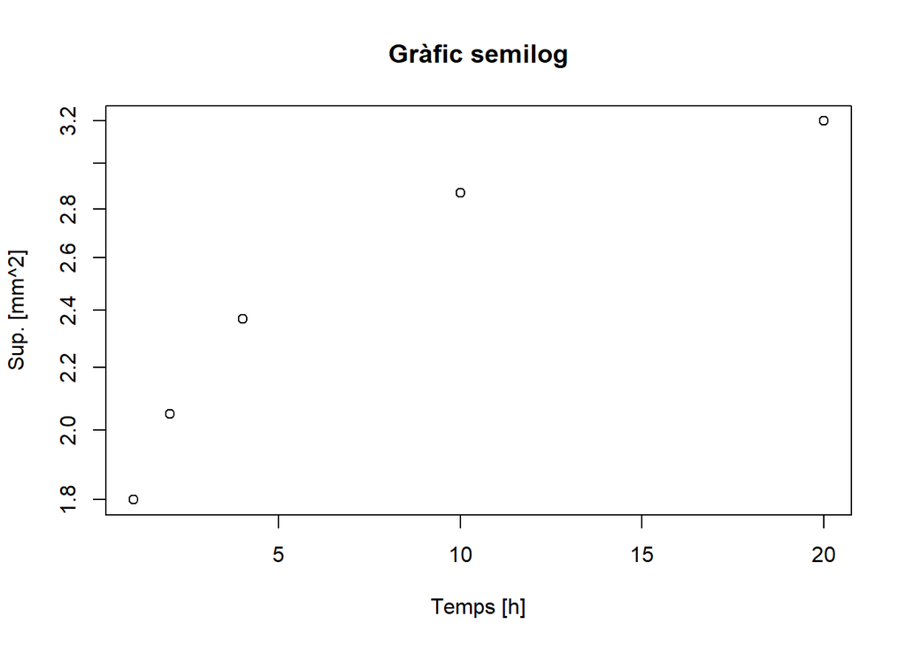

```r
plot(t, s, xlab="Temps [h]", ylab="Sup. [mm^2]",
     main="Gràfic semilog", log="y")
```

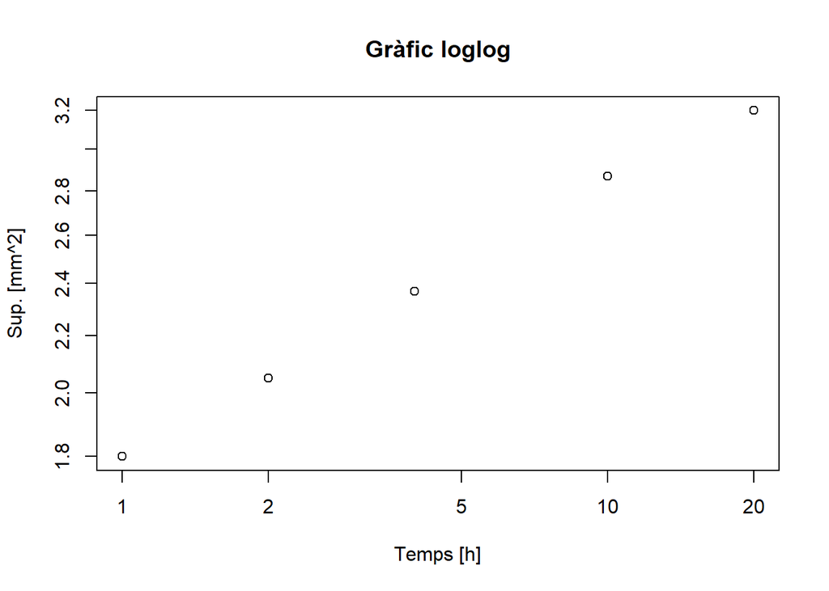

```r
plot(t, s, xlab="Temps [h]", ylab="Sup. [mm^2]",
     main="Gràfic loglog", log="xy")
```

De nou, els punts es troben més alineats en el gràfic loglog, el que indica que és una relació potencial. Trobem ara el model potencial:

```r
model_loglog = lm(log10(s) ~ log10(t))
summary(model_loglog)
```

```
##
## Call:
## lm(formula = log10(s) ~ log10(t))
##
## Residuals:
##          1          2          3          4          5
## -0.0002104 -0.0026731  0.0013773  0.0065911 -0.0050849
##
## Coefficients:
##             Estimate Std. Error t value Pr(>|t|)
## (Intercept) 0.255483   0.003879   65.86 7.71e-06 ***
## log10(t)    0.195808   0.004890   40.04 3.43e-05 ***
## ---
## Signif. codes:  0 '***' 0.001 '**' 0.01 '*' 0.05 '.' 0.1 ' ' 1
##
## Residual standard error: 0.005112 on 3 degrees of freedom
## Multiple R-squared:  0.9981, Adjusted R-squared:  0.9975
## F-statistic:  1603 on 1 and 3 DF,  p-value: 3.428e-05
```

És a dir,

$$\log(s) = 0.2554 + 0.1958 \log(t) \Rightarrow s = 10^{0.2554} \cdot t^{0.1958}.$$